# Notebook

### Фактический запуск 14.09.2026

Все вычислительные ячейки выполнены. Техническое исполнение не подтверждает научные интерпретации исторического текста. Полный журнал — `legacy-execution.json`.

## Статус воспроизведения исторической редакции

Повторный технический запуск не подтверждает научные выводы старой редакции. Ниже сохранены прежние допущения и интерпретации; их следует сверять с текущими правилами проекта. Дыхательная и ЭКГ-разметка исторических расчётов не получает статус принятой при повторном запуске. Значения толщины 15 и 40 мм — исторические сценарии, а не заново проверенные измерения по КТ. Старые оценки сердечного происхождения сигнала и функций сердца не считаются валидированными.

```
Исторические входы скопированы; запись в исходные метки и параметры исключена.
```

# Полный санированный снимок 30.05 до переработки

> **Статус:** архивный смешанный источник, не активный расчёт и не научный результат.
- Снимок: `../../30.05_Масштабные_законы_двуслойной_модели.ipynb`.
- Коммит до переработки: `b5bc9b62ba0af99f29ef218084e9a5fcedab8d67`.
- Исторический источник: `Colab Notebooks/12_Аналитическое_обоснование.ipynb`.
- Все исходные cell IDs и тексты сохранены; outputs и execution counts очищены.

В старом notebook смешаны масштабные законы, условная CRLB-постановка, субъектные интерпретации и гипотеза модельного несоответствия. После переработки масштабные тождества принадлежат `30.05`, а статистическая идентифицируемость и выбор размеров — сериям `31` и `32`.

# Аналитическое обоснование негативных результатов (без данных)

Чисто модельный расчёт: почему при толстых тканях ρ₂ неидентифицируем, облако решений разваливается, а Δρ₁ ловит ошибку модели. Всё выводится из прямой формулы и её производных — **без экспериментальных данных**. Это мост к МКЭ (после — расчёт по конечно-элементным моделям в MATLAB).

## §0. Назначение анализа и словарь терминов

### Решаемая задача

Требуется показать аналитически, без обращения к данным, что негативные результаты работы (неопределимость удельного сопротивления лёгкого ρ₂ при толстом слое мягких тканей, широкий разброс оценки и появление ложного пульсового приращения мягких тканей Δρ₁) — не дефекты данных, а следствия свойств самой двуслойной модели. Этот раздел служит эталоном для сравнения с последующим конечноэлементным расчётом по реальной геометрии.

### Метод и обоснование выбора

Используются свойства прямой задачи двуслойной модели: масштабная инвариантность (форма зависимости определяется только безразмерной глубиной), асимптотическое поведение чувствительности и граница Крамера–Рао для неопределённости оценки. Аналитический подход выбран потому, что он отделяет ограничения модели от особенностей конкретных измерений.

### Словарь терминов

Основные термины (двуслойная модель, электродная сборка, эластичность, показатель качества, матрица Фишера) определены в §0 ноутбуков 09 и 05. Дополнительно:

- **Безразмерная глубина** η = h/a — отношение толщины слоя мягких тканей к токовой полубазе сборки; определяет форму зависимости импеданса от параметров.
- **Масштабная инвариантность** — свойство модели, при котором приведённый импеданс и эластичности зависят только от безразмерной глубины, формы сборки и контраста, но не от абсолютных размеров по отдельности.
- **Коллапс чувствительности** — быстрое (примерно как обратный куб безразмерной глубины) убывание эластичности по ρ₂ с ростом глубины; означает потерю информации о лёгком при толстом слое мягких тканей.
- **Граница Крамера–Рао** — нижняя граница дисперсии несмещённой оценки, вычисляемая по матрице Фишера ([вторичный источник](https://ru.wikipedia.org/wiki/%D0%9D%D0%B5%D1%80%D0%B0%D0%B2%D0%B5%D0%BD%D1%81%D1%82%D0%B2%D0%BE_%D0%9A%D1%80%D0%B0%D0%BC%D0%B5%D1%80%D0%B0_%E2%80%94_%D0%A0%D0%B0%D0%BE)).
- **Критический размер сборки** — наименьший размер, при котором эластичность по ρ₂ достигает порога; растёт линейно с толщиной слоя мягких тканей.

### Формулы

Безразмерная глубина, формула (12.1):

$$\eta=\frac{h}{a} \tag{12.1}$$

где η — безразмерная глубина; h — толщина слоя мягких тканей, м; a — токовая полубаза сборки, м.

Масштабная инвариантность импеданса, формула (12.2):

$$Z=\frac{\rho_1}{a}\,\Phi(\beta,\eta,k) \tag{12.2}$$

где Φ — безразмерная функция; β = b/a — форма сборки; k = (ρ₂ − ρ₁)/(ρ₂ + ρ₁) — контраст. Форма зависимости и эластичности определяются только (β, η, k).

Асимптотический коллапс чувствительности к лёгкому, формула (12.3):

$$S_{\rho_2}\ \sim\ \frac{1}{\eta^{3}}\quad (\eta\gg1) \tag{12.3}$$

где S_ρ₂ — эластичность импеданса по ρ₂ (§0 05). При большой глубине чувствительность к лёгкому убывает примерно как обратный куб глубины.

**Входные данные.** Рабочая точка анализа: удельные сопротивления ρ₁ = 6, ρ₂ = 18 Ом·м; данные не используются.

**Допущения.** Импеданс, производные и эластичности двуслойной модели заданы аналитически (§0 05); анализ самодостаточен и не зависит от измерений.

```
Модель и производные готовы. Рабочая точка ρ1=6, ρ2=18 Ом·м.
```

**Анализ результатов.** Модель, производные и эластичности определены в рабочей точке.

**Результаты и умозаключения.** Эти функции — общий вход для всех разделов анализа.

## §1. Форма зависимости определяется безразмерной глубиной $\eta=h/a$

**Входные данные.** Приведённый импеданс и эластичность по ρ₂ при разных значениях безразмерной глубины (12.1) и двух масштабах абсолютного размера.

**Допущения.** Чтобы проверить масштабную инвариантность (12.2), приведённый импеданс и эластичность вычисляются при одинаковой безразмерной глубине, но разных абсолютных размерах: они должны совпасть.

```
η     | Z·a/ρ1 (масштаб ×1, ×3)        | S_ρ2 (×1, ×3)
0.3   | 0.68621 / 0.68621 (совпали: True) | 0.3597 / 0.3597
0.6   | 0.51420 / 0.51420 (совпали: True) | 0.1502 / 0.1502
1.0   | 0.45417 / 0.45417 (совпали: True) | 0.0546 / 0.0546

Вывод: форма зависимости и чувствительность — функции ТОЛЬКО η=h/a (и β,k). Толщина входит лишь через η.
```

**Анализ результатов.** При изменении абсолютного масштаба в три раза приведённый импеданс и эластичность по ρ₂ не меняются (совпадают при каждом значении η). Форма зависимости и чувствительность — функции только безразмерной глубины, формы и контраста.

**Результаты и умозаключения.** Толщина входит в задачу только через безразмерную глубину η = h/a; поэтому любой порог чувствительности задаёт условие на η, а не на абсолютную толщину.

## §2. Чувствительность к $\rho_2$ убывает примерно как $1/\eta^{3}$

**Входные данные.** Эластичность по ρ₂ как функция безразмерной глубины; положения Ника и Георгия на этой зависимости.

**Допущения.** Чтобы показать потерю чувствительности к лёгкому при толстом слое, строится зависимость эластичности по ρ₂ от глубины и проверяется асимптотика (12.3).

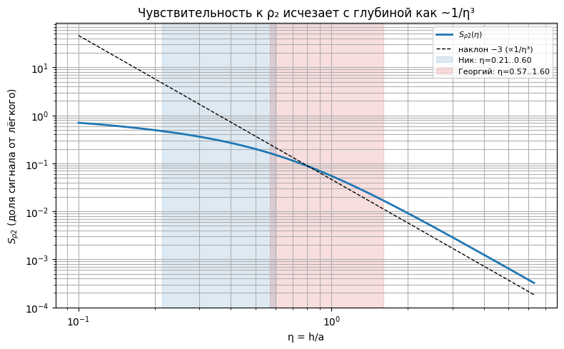

```
Георгий (толстые ткани) сидит в зоне высокого η -> S_ρ2 в разы меньше, чем у Ника.
```

**Анализ результатов.** Эластичность по ρ₂ убывает с глубиной примерно как обратный куб; Георгий (толстый слой) находится в зоне большой глубины, где эластичность в разы меньше, чем у Ника.

**Результаты и умозаключения.** При толстом слое мягких тканей чувствительность импеданса к ρ₂ мала независимо от объекта; это первопричина неопределимости ρ₂ у Георгия (09 §3.1).

## §3. Неопределённость $\rho_2$ растёт с толщиной (граница Крамера–Рао)

**Входные данные.** Матрица Фишера набора размеров 50–140 мм (§0 05) при разной толщине.

**Допущения.** Чтобы связать чувствительность с неопределённостью оценки, стандартное отклонение оценки ρ₂ вычисляется по границе Крамера–Рао как функция толщины.

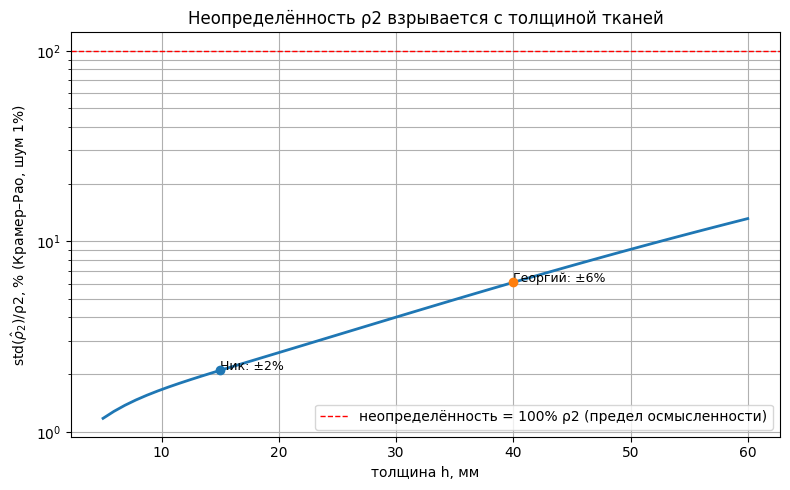

[output not shown]

## §4. Усиление ошибки толщины и расширение облака (угол между кривыми уменьшается)

**Входные данные.** Показатель качества сигнал/помеха и угол между кривыми равного импеданса по размерам сборок как функция толщины.

**Допущения.** Чтобы объяснить расширение облака пересечений, вычисляются показатель качества (§0 05) и угол между кривыми; малый угол усиливает разброс пересечений.

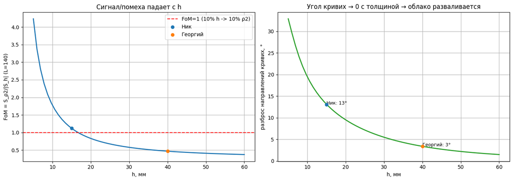

```
Толстые ткани: FoM<1 (ошибка h усиливается) и угол кривих мал (1/sinθ велик) -> облако в разы шире.
```

**Анализ результатов.** При толстом слое показатель качества меньше единицы (ошибка толщины усиливается), а угол между кривыми мал, поэтому разброс облака велик.

**Результаты и умозаключения.** Расширение облака у Георгия — следствие обусловленности (малого угла и низкого показателя качества), а не ошибки данных (09 §4–5).

## §5. По одной сборке разделение невозможно; ошибка глубины источника даёт ложное $\Delta\rho_1$

**Входные данные.** Модельный систолический размах при разной глубине пульсового источника (источник смещается вглубь от однородного полупространства).

**Допущения.** Чтобы показать происхождение ложного Δρ₁, в модель вносится ошибка глубины источника, и по двуслойной модели восстанавливаются Δρ₁ и Δρ₂. При верной модели (нулевом смещении) Δρ₁ должно быть строго нулём.

```
Δd, мм | восстановл. Δρ1 (ложное) | Δρ2 | трактовка
----------------------------------------------------------------
   0   |      -0.0000 Ом·м       | 0.0800 | Δρ1=0 (нет ошибки)
   5   |      -0.0003 Ом·м       | 0.0603 | ошибка глубины -> ложное Δρ1≠0
  10   |      -0.0003 Ом·м       | 0.0462 | ошибка глубины -> ложное Δρ1≠0
  20   |      -0.0003 Ом·м       | 0.0283 | ошибка глубины -> ложное Δρ1≠0

Вывод: при ВЕРНОЙ модели (Δd=0) Δρ1=0 точно. Любое несоответствие глубины источника
плоской двуслойной модели проецируется в Δρ1 -> это систематический предел (нужен МКЭ).
```

**Анализ результатов.** При нулевом смещении Δρ₁ = 0 точно. Любое смещение источника вглубь даёт ненулевое (ложное) Δρ₁ и уменьшает восстановленное Δρ₂.

**Результаты и умозаключения.** Ложное Δρ₁ возникает, когда пульсовой источник (сердце, крупные сосуды) лежит глубже однородного полупространства модели; это модельная систематика, а не пульсация мягких тканей (11 §3.3). Устранение требует глубинно-разрешённой модели (конечноэлементный расчёт по томографии).

## §6. Критический размер сборки растёт с толщиной: диапазон 50–140 мм для Георгия недостаточен

**Входные данные.** Критический размер сборки (по порогу эластичности к ρ₂) как функция толщины.

**Допущения.** Чтобы оценить достаточность имеющихся размеров, вычисляется наименьший размер сборки, при котором эластичность по ρ₂ достигает порога; ожидается линейный рост с толщиной.

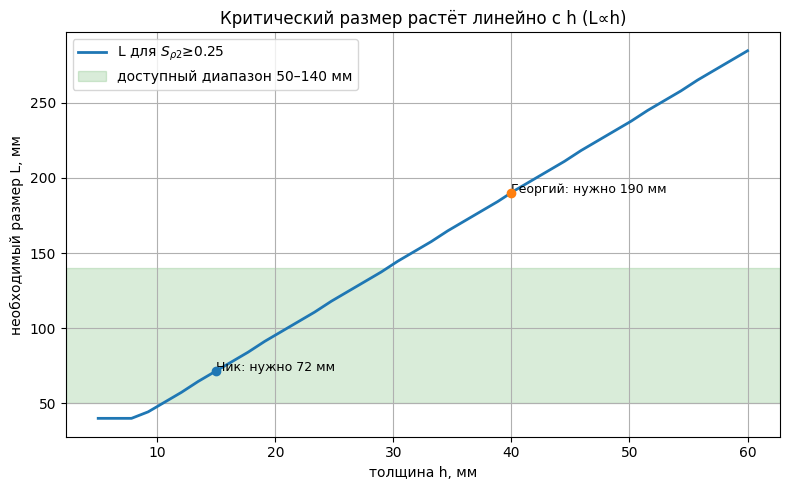

```
Ник: порог достигается внутри 50–140. Георгий: нужно L много больше 140 -> текущими решётками ρ2 не взять.
```

**Анализ результатов.** У Ника порог достигается внутри диапазона 50–140 мм; у Георгия требуется размер существенно больше 140 мм.

**Результаты и умозаключения.** Текущий диапазон размеров достаточен для тонкого слоя мягких тканей и недостаточен для толстого; это обосновывает расширение набора размеров вверх (05 §8) и служит эталоном для конечноэлементного расчёта (§7).

## §7. Выводы и мост к МКЭ

**Все негативные результаты — следствия двух фактов:**

**Что снимает МКЭ по геометрии КТ (следующий шаг, MATLAB):**

- **глубинно-разрешённый источник** — пульсация на правильной глубине (сердце/сосуды/лёгкое) убирает протекание в Δρ₁ (§5);
- **реальная геометрия** (рёбра, кривизна) — даёт верхнюю границу $L_{\max}$ и позволяет крупные базы, возвращающие $S_{\rho_2}$ при толстых тканях (§2,§6);
- **проверка плоской формулы**: сравнение $Z_{\text{МКЭ}}(L)$ с аналитической $Z(L)$ количественно очерчивает зону применимости.

Эти аналитические зависимости (S_ρ2(η), std(ρ2)(h), FoM, L(h)) — эталон, с которым будем сверять МКЭ.